# Project Foundations for Data Science: FoodHub Data Analysis

**Marks: 60**

### Context

The number of restaurants in New York is increasing day by day. Lots of students and busy professionals rely on those restaurants due to their hectic lifestyles. Online food delivery service is a great option for them. It provides them with good food from their favorite restaurants. A food aggregator company FoodHub offers access to multiple restaurants through a single smartphone app.

The app allows the restaurants to receive a direct online order from a customer. The app assigns a delivery person from the company to pick up the order after it is confirmed by the restaurant. The delivery person then uses the map to reach the restaurant and waits for the food package. Once the food package is handed over to the delivery person, he/she confirms the pick-up in the app and travels to the customer's location to deliver the food. The delivery person confirms the drop-off in the app after delivering the food package to the customer. The customer can rate the order in the app. The food aggregator earns money by collecting a fixed margin of the delivery order from the restaurants.

### Objective

The food aggregator company has stored the data of the different orders made by the registered customers in their online portal. They want to analyze the data to get a fair idea about the demand of different restaurants which will help them in enhancing their customer experience. Suppose you are hired as a Data Scientist in this company and the Data Science team has shared some of the key questions that need to be answered. Perform the data analysis to find answers to these questions that will help the company to improve the business.

### Data Description

The data contains the different data related to a food order. The detailed data dictionary is given below.

### Data Dictionary

- order_id: Unique ID of the order
- customer_id: ID of the customer who ordered the food
- restaurant_name: Name of the restaurant
- cuisine_type: Cuisine ordered by the customer
- cost: Cost of the order
- day_of_the_week: Indicates whether the order is placed on a weekday or weekend (The weekday is from Monday to Friday and the weekend is Saturday and Sunday)
- rating: Rating given by the customer out of 5
- food_preparation_time: Time (in minutes) taken by the restaurant to prepare the food. This is calculated by taking the difference between the timestamps of the restaurant's order confirmation and the delivery person's pick-up confirmation.
- delivery_time: Time (in minutes) taken by the delivery person to deliver the food package. This is calculated by taking the difference between the timestamps of the delivery person's pick-up confirmation and drop-off information

### Let us start by importing the required libraries

```python
# import libraries for data manipulation
import numpy as np
import pandas as pd

# import libraries for data visualization
import matplotlib.pyplot as plt
import seaborn as sns
```

```python
# Library to suppress warnings
import warnings
warnings.filterwarnings('ignore')
```

### Understanding the structure of the data

```python
# read the data
df = pd.read_csv('foodhub_order.csv')
# returns the first 5 rows
df.head()
```

|  | order_id | customer_id | restaurant_name | cuisine_type | cost_of_the_order | day_of_the_week | rating | food_preparation_time | delivery_time |
| --- | --- | --- | --- | --- | --- | --- | --- | --- | --- |
| 0 | 1477147 | 337525 | Hangawi | Korean | 30.75 | Weekend | Not given | 25 | 20 |
| 1 | 1477685 | 358141 | Blue Ribbon Sushi Izakaya | Japanese | 12.08 | Weekend | Not given | 25 | 23 |
| 2 | 1477070 | 66393 | Cafe Habana | Mexican | 12.23 | Weekday | 5 | 23 | 28 |
| 3 | 1477334 | 106968 | Blue Ribbon Fried Chicken | American | 29.20 | Weekend | 3 | 25 | 15 |
| 4 | 1478249 | 76942 | Dirty Bird to Go | American | 11.59 | Weekday | 4 | 25 | 24 |

#### Observations:

The DataFrame has 9 columns as mentioned in the Data Dictionary. Data in each row corresponds to the order placed by a customer.

### **Question 1:** How many rows and columns are present in the data? [0.5 mark]

```python
# using .shape to show the size of the dataframe
print("Number of rows:", df.shape[0], "  Number of columns:", df.shape[1])
```

```
Number of rows: 1898   Number of columns: 9
```

#### Observations:

Data has 1898 rows and 9 columns

### **Question 2:** What are the datatypes of the different columns in the dataset? (The info() function can be used) [0.5 mark]

```python
# Use info() to print a concise summary of the DataFrame
df.info()
```

```
<class 'pandas.core.frame.DataFrame'>
RangeIndex: 1898 entries, 0 to 1897
Data columns (total 9 columns):
 #   Column                 Non-Null Count  Dtype
---  ------                 --------------  -----
 0   order_id               1898 non-null   int64
 1   customer_id            1898 non-null   int64
 2   restaurant_name        1898 non-null   object
 3   cuisine_type           1898 non-null   object
 4   cost_of_the_order      1898 non-null   float64
 5   day_of_the_week        1898 non-null   object
 6   rating                 1898 non-null   object
 7   food_preparation_time  1898 non-null   int64
 8   delivery_time          1898 non-null   int64
dtypes: float64(1), int64(4), object(4)
memory usage: 133.6+ KB
```

#### Observations:

Data has datatypes of 4 x int64, 1 x float64 and 4 x objects(string) as specified in the info() output

### **Question 3:** Are there any missing values in the data? If yes, treat them using an appropriate method. [1 mark]

```python
# Count the number of null values in each column
df.isnull().sum()
```

|  | 0 |
| --- | --- |
| order_id | 0 |
| customer_id | 0 |
| restaurant_name | 0 |
| cuisine_type | 0 |
| cost_of_the_order | 0 |
| day_of_the_week | 0 |
| rating | 0 |
| food_preparation_time | 0 |
| delivery_time | 0 |

**dtype:** int64

There are no null values in the original data, but we notice that 'rating' is an object where it should be numerical. We should check which non-numeric values are stored in 'rating'.

```python
# Check all the unique values of 'rating'.
# This will show us which non numerical values are stored in 'rating'.

df['rating'].unique()
```

```
array(['Not given', '5', '3', '4'], dtype=object)
```

The column 'rating' contains the string "Not given" for missing values, so we need to replace it with Nan. Using np.nan will allow us to do calculations on the 'rating' column.

```python
# Replace the string values with nan
df['rating'] = df['rating'].replace('Not given',np.nan)

# Change the data type to float
df['rating'] = df['rating'].astype(float)
df['rating'].head()
```

|  | rating |
| --- | --- |
| 0 | NaN |
| 1 | NaN |
| 2 | 5.0 |
| 3 | 3.0 |
| 4 | 4.0 |

**dtype:** float64

```python
# Count number of nulls in ratings
nan_rating = df['rating'].isnull().sum()
print('Number of missing rating values:', nan_rating, '(', round(nan_rating/df.shape[0]*100, 2), '%)')

# Replace NaN values in 'rating' with the mean -<< NOT NOW
# df['rating'] = df['rating'].fillna(round(df['rating'].mean(),1))
```

```
Number of missing rating values: 736 ( 38.78 %)
```

#### Observations:

38.78% of the 'rating' is missing. The rating is distributed between 3-5. We can calculate the mean to replace missing values, but looking at questions ahead I decided to leave the missing values as np.nan

### **Question 4:** Check the statistical summary of the data. What is the minimum, average, and maximum time it takes for food to be prepared once an order is placed? [2 marks]

```python
# Statistical summary of all the numerical data
df.describe(exclude=[object]).round(2).T
```

|  | count | mean | std | min | 25% | 50% | 75% | max |
| --- | --- | --- | --- | --- | --- | --- | --- | --- |
| order_id | 1898.0 | 1477495.50 | 548.05 | 1476547.00 | 1477021.25 | 1477495.50 | 1477969.75 | 1478444.00 |
| customer_id | 1898.0 | 171168.48 | 113698.14 | 1311.00 | 77787.75 | 128600.00 | 270525.00 | 405334.00 |
| cost_of_the_order | 1898.0 | 16.50 | 7.48 | 4.47 | 12.08 | 14.14 | 22.30 | 35.41 |
| rating | 1162.0 | 4.34 | 0.74 | 3.00 | 4.00 | 5.00 | 5.00 | 5.00 |
| food_preparation_time | 1898.0 | 27.37 | 4.63 | 20.00 | 23.00 | 27.00 | 31.00 | 35.00 |
| delivery_time | 1898.0 | 24.16 | 4.97 | 15.00 | 20.00 | 25.00 | 28.00 | 33.00 |

```python
# Check statistical summary of 'food_preparation_time'

print(df['food_preparation_time'].describe().round(2))
```

```
count    1898.00
mean       27.37
std         4.63
min        20.00
25%        23.00
50%        27.00
75%        31.00
max        35.00
Name: food_preparation_time, dtype: float64
```

#### Observations:

The time it takes for food to be prepared once an order is placed: minimum = 20 mintutes, average = 27.37 minutes, and maximum = 35 minutes.

### **Question 5:** How many orders are not rated? [1 mark]

```python
# as calculated in question 3, we count the NaN values in rating
print('Number of missing rating values:', nan_rating, '(', round(nan_rating/df.shape[0]*100, 2), '%)')
```

```
Number of missing rating values: 736 ( 38.78 %)
```

#### Observations:

As calculated and extracted in question 3, the number of missing rating values is 736 ( 38.78 % of the data)

### Exploratory Data Analysis (EDA)

### **Question 6:** Explore all the variables and provide observations on their distributions. (Generally, histograms, boxplots, countplots, etc. are used for univariate exploration.) [9 marks]

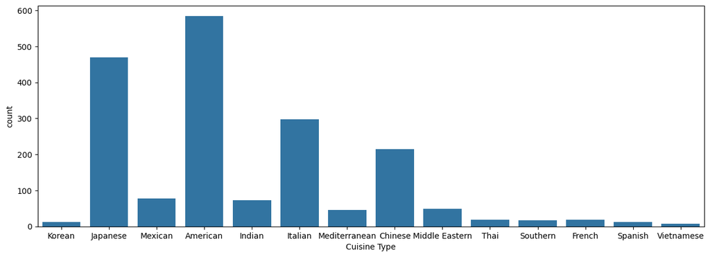

```python
# Create a countplot for cuisine type
plt.figure(figsize = (15,5))
sns.countplot(data = df, x = 'cuisine_type');
plt.xlabel('Cuisine Type');
```

```python
# Check number of cuisines
print ('Number of unique cuisine types:', df['cuisine_type'].nunique() )
```

```
Number of unique cuisine types: 14
```

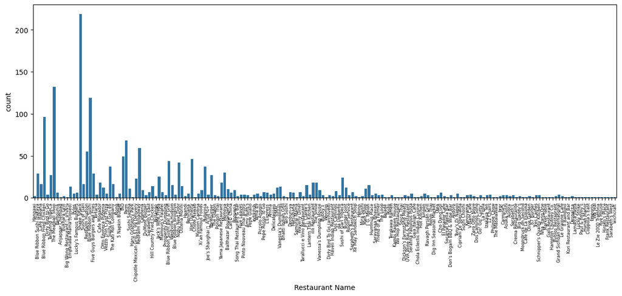

```python
# Create a countplot for restaurant name
plt.figure(figsize = (15,5))
sns.countplot(data = df, x = 'restaurant_name');
plt.xlabel('Restaurant Name');
plt.xticks(rotation = 90, fontsize=6);
```

```python
# Check number of restaurants in data
print ('Number of restaurants:', df['restaurant_name'].nunique())
```

```
Number of restaurants: 178
```

```python
# Check number of unique customers in data
print ('Number of costumers:', df['customer_id'].nunique())
```

```
Number of costumers: 1200
```

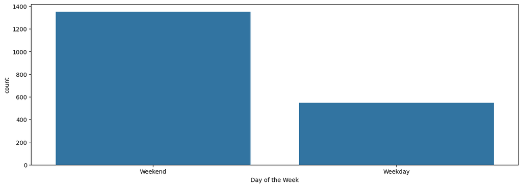

```python
# Create a countplot for day_of_the_week
plt.figure(figsize = (15,5))
sns.countplot(data = df, x = 'day_of_the_week');
plt.xlabel('Day of the Week');
```

```python
# Define function to draw histogram and boxplot
# We use the function to visualize different parameters without repeating the code
def draw_hist_box(data, param):
  '''Draw histogram and boxplot of a parameter param from data'''
  if param in data.columns:
    param_title = param.replace('_', ' ').title() # Format param name to use as title

    plt.figure(figsize=(12, 6))

    # Histogram
    plt.subplot(2, 1, 1) # Drawing histogram on upper subplot
    sns.histplot(data=data, x=param, kde=True)
    plt.title('Histogram of '+param_title)
    plt.xlabel("")

    # Boxplot
    plt.subplot(2, 1, 2) # Drawing boxplot on lower subplot
    sns.boxplot(data=data, x=param)
    plt.title('Boxplot of '+param_title)
    plt.xlabel("")

    plt.tight_layout() # Adjusts subplot parameters for a tight layout.
    plt.show()
  else:
    print(f"Column '{param}' not found in the DataFrame.")
```

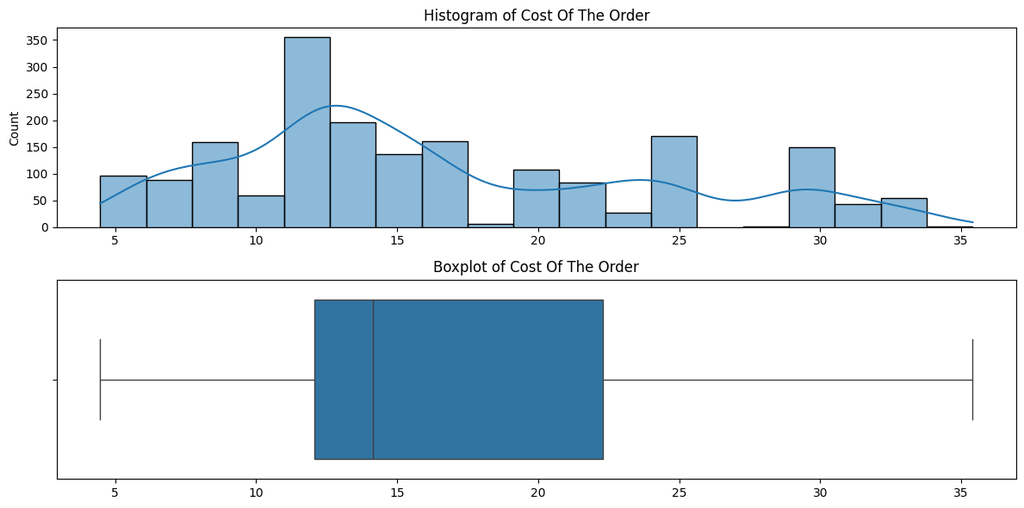

```python
# Draw histogram and boxplot of cost_of_the_order using the function
draw_hist_box(df, 'cost_of_the_order')
```

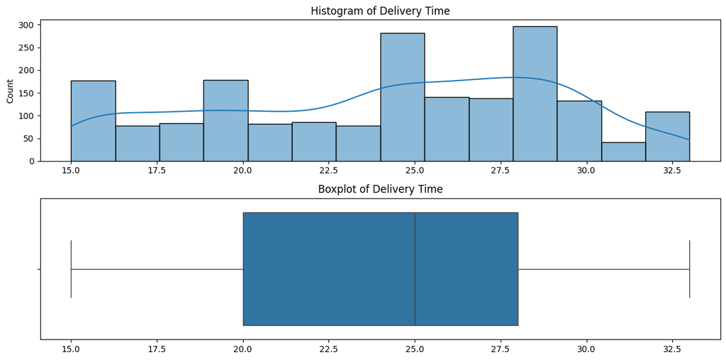

```python
# Draw histogram and boxplot of delivery_time
draw_hist_box(df, 'delivery_time')
```

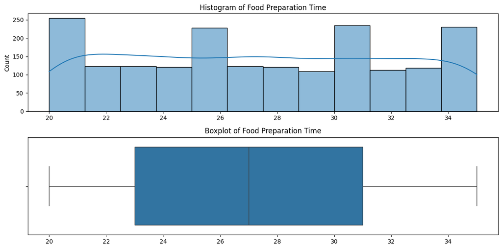

```python
# Draw histogram and boxplot of food_preparation_time
draw_hist_box(df, 'food_preparation_time')
```

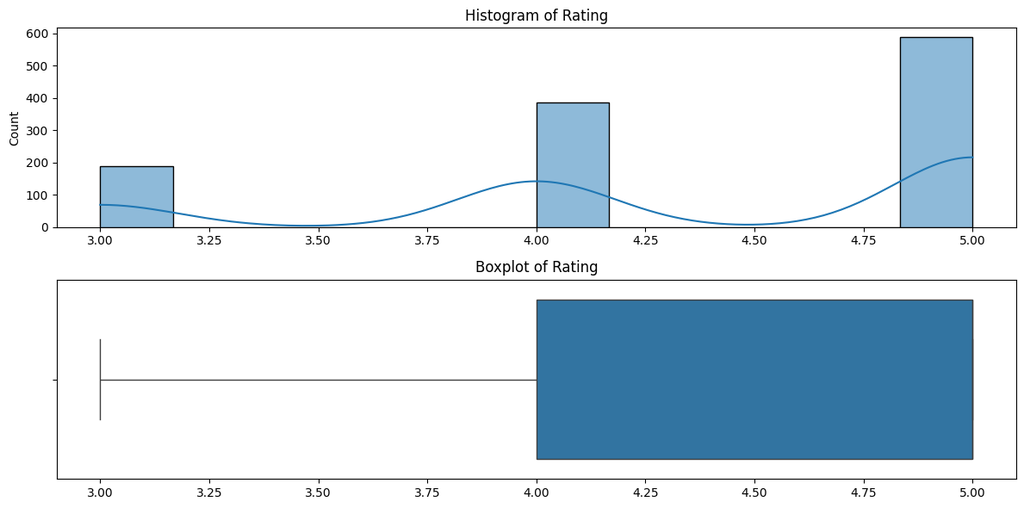

```python
# Draw histogram and boxplot of rating
draw_hist_box(df, 'rating')
```

### **Question 7**: Which are the top 5 restaurants in terms of the number of orders received? [1 mark]

```python
# We use value_counts to get the frequency of each unique value (restaurant name)
# value_counts returns a sorted list of frequencies in descending order
# we display the top 5 of the sorted list -> the top 5 restaurants

df['restaurant_name'].value_counts()[:5]
df_top5 = df['restaurant_name'].value_counts()[:5].reset_index().copy()

# Get cuisine_type of each restaurant in df_top5
df_top5['cuisine_type'] = df_top5['restaurant_name'].apply(lambda x: df[df['restaurant_name'] == x]['cuisine_type'].unique()[0])
df_top5
```

|  | restaurant_name | count | cuisine_type |
| --- | --- | --- | --- |
| 0 | Shake Shack | 219 | American |
| 1 | The Meatball Shop | 132 | Italian |
| 2 | Blue Ribbon Sushi | 119 | Japanese |
| 3 | Blue Ribbon Fried Chicken | 96 | American |
| 4 | Parm | 68 | Italian |

### **Question 8**: Which is the most popular cuisine on weekends? [1 mark]

```python
# We first filter the dataframe to show only rows with day_of_the_week==weekend
# We then use value_counts to count the frequency of each cuisine_type
# for the most popular in the list we show the first result

df['cuisine_type'][df['day_of_the_week'] == 'Weekend'].value_counts().index[0]
```

```
'American'
```

#### Observations:

American cuisine is the most popular during weekends.

### **Question 9**: What percentage of the orders cost more than 20 dollars? [2 marks]

```python
# We filter the dataframe for column 'cost_of_order' > 20
# The number of rows in the filtered dataframe (.shape[0]) is the number of orders cost > 20
# Dividing by the total number of orders (df.shape[0]) gives the percentage
# Use round to get a more readable number

round( df[df['cost_of_the_order']>20].shape[0]/df.shape[0]*100, 2)
```

```
29.24
```

#### Observations:

29.24% of the orders cost more than 20$

### **Question 10**: What is the mean order delivery time? [1 mark]

```python
# We use pandas mean() to calculate the mean of column delivery_time

round( df['delivery_time'].mean(), 2)
```

```
24.16
```

#### Observations:

The mean of order delivery time is 24.16 minutes.

### **Question 11:** The company has decided to give 20% discount vouchers to the top 3 most frequent customers. Find the IDs of these customers and the number of orders they placed. [1 mark]

```python
# We use value_counts() to count the frequency of each unique customer id
# and print the top 3 from the sorted list

df['customer_id'].value_counts()[:3]
```

| customer_id | count |
| --- | --- |
| 52832 | 13 |
| 47440 | 10 |
| 83287 | 9 |

**dtype:** int64

#### Observations:

Top most frequent customers are those with ids: 52832, 47440, 83287

### **Question 12**: Perform a multivariate analysis to explore relationships between the important variables in the dataset. (It is a good idea to explore relations between numerical variables as well as relations between numerical and categorical variables) [10 marks]

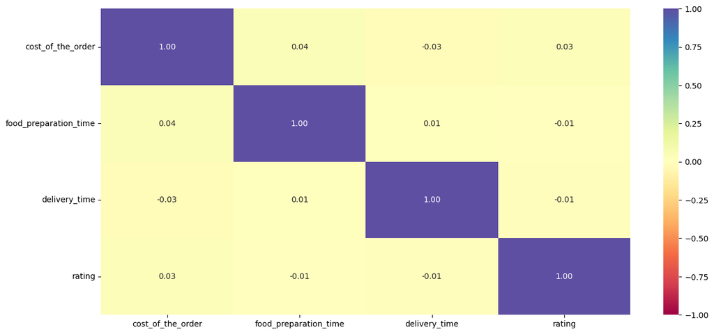

```python
# We start with checking the correlation between numerical variables
# Plot the heatmap
col_list = ['cost_of_the_order', 'food_preparation_time', 'delivery_time', 'rating']
plt.figure(figsize=(15, 7))
sns.heatmap(df[col_list].corr(), annot=True, vmin=-1, vmax=1, fmt=".2f", cmap="Spectral")
plt.show()
```

```python
# Function to plot relationship boxplots between x and y, including the means.
# The boxplot shows the median and IQR of variable. We also add the mean value
# as a red circle to add more information about the variable.
# Adding hue to the graph is optional.
# We'll use this function to show relationships between different variables.

def relationship(x, y, data, hue=''):
  '''Draw relationship boxplots between x and y, including the means. hue is optional'''

  if x in data.columns and y in data.columns: # make sure x,y are in the dataframe
    # Define plot size
    plt.figure(figsize=(15,7))

    # Create the boxplot. Add hue if specified in input
    if hue in data.columns:
      ax = sns.boxplot(x=x, y=y, data=data, hue=hue)
    else:
      ax = sns.boxplot(x=x, y=y, data=data)

    # Format variable names to use in labels
    x_title = x.replace('_', ' ').title()
    y_title = y.replace('_', ' ').title()
    plt.title(f"Relationship between '{x}' and '{y}'")
    plt.xlabel(x_title)
    plt.ylabel(y_title)

    # Calculate and add the mean for each x value
    x_values = data[x].dropna().unique() # list of all non-NaN unique values
    for x_val in x_values:
        mean_value = data[data[x] == x_val][y].mean()
        ax.plot(np.where(x_values == x_val)[0], [mean_value], marker='o', color='red', markersize=8)

    # Rotate x-axis labels for better readability if labels are too long
    max_label_length = max([len(str(label)) for label in x_values])
    if max_label_length > 100/len(x_values):
      plt.xticks(rotation=45)

    # Show the plot
    plt.show()

  else:
    print(f"Column '{x}' or '{y}' not found in the DataFrame.")
```

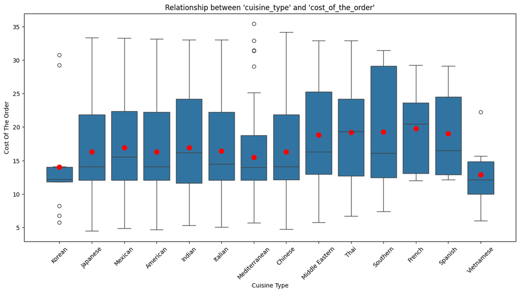

```python
# Relationship between cost of the order and cuisine type
relationship(x = "cuisine_type", y = "cost_of_the_order", data = df)
```

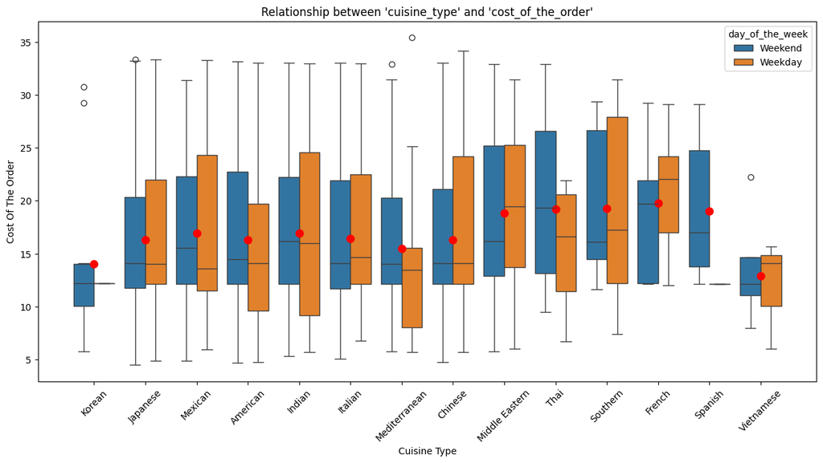

```python
# Relationship between cost of the order and cuisine type. Differentiate between day of the week
relationship(x = "cuisine_type", y = "cost_of_the_order", data = df, hue="day_of_the_week")
```

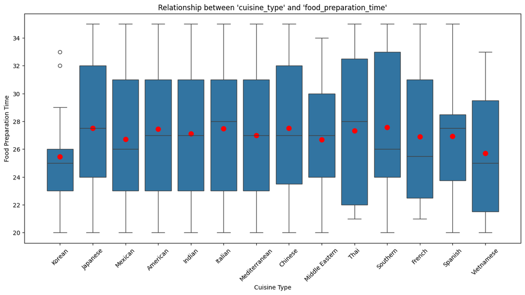

```python
# Relationship between food preparation time and cuisine type
relationship(x = "cuisine_type", y = "food_preparation_time", data = df)
```

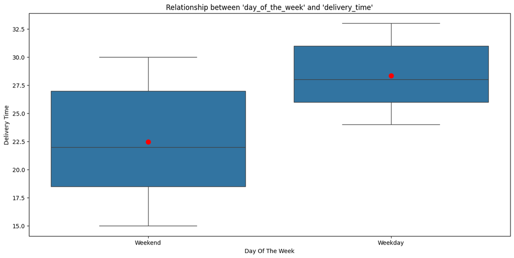

```python
# Relationship between day of the week and delivery time
relationship(x = "day_of_the_week", y = "delivery_time", data = df)
```

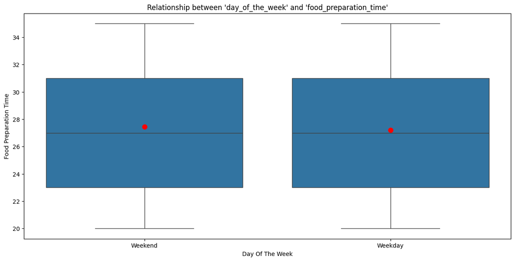

```python
# Relationship between day of the week and food preparation time
relationship(x = "day_of_the_week", y = "food_preparation_time", data = df)
```

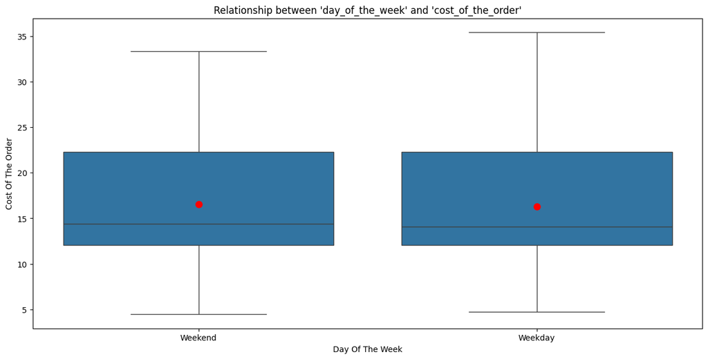

```python
# Relationship between day of the week and cost of the order
relationship(x = "day_of_the_week", y = "cost_of_the_order", data = df)
```

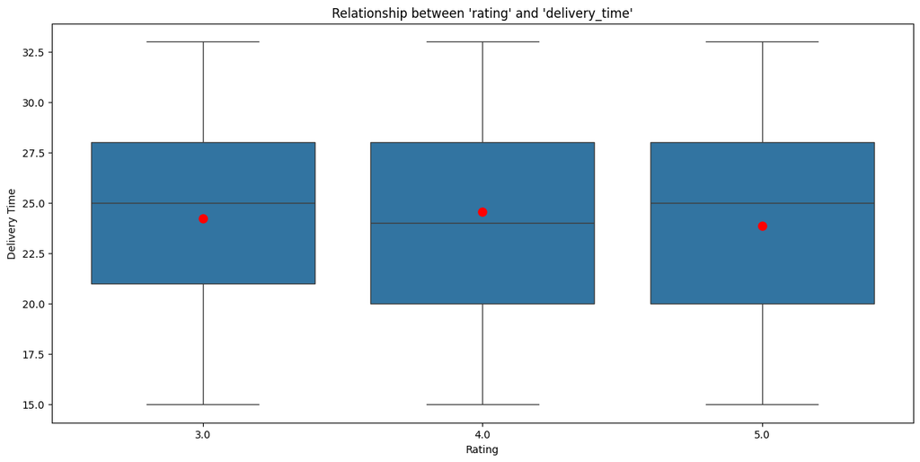

```python
# Relationship between rating and delivery time
relationship(x = "rating", y = "delivery_time", data=df)
```

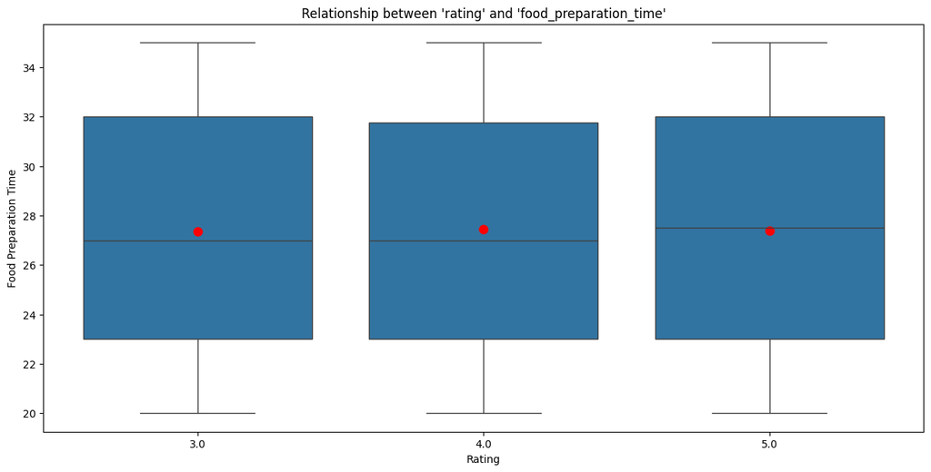

```python
# Relationship between rating and food preparation time
relationship(x = "rating", y = "food_preparation_time", data=df)
```

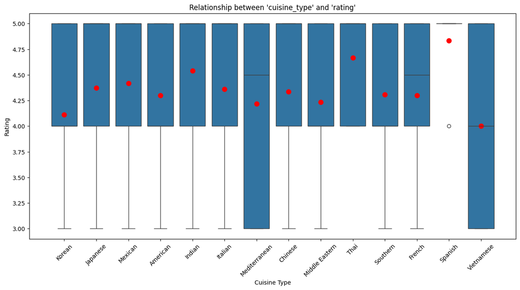

```python
# Relationship between rating and food cuisine type
relationship(x = "cuisine_type", y = "rating", data=df)
```

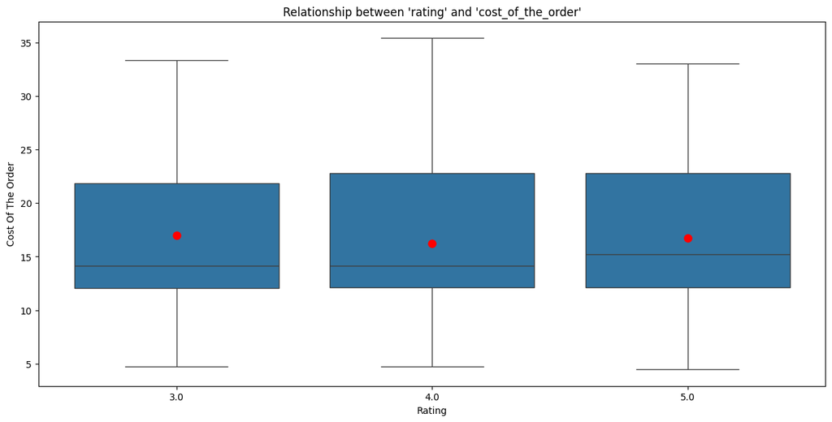

```python
# Relationship between rating and cost of the order
relationship(x = "rating", y = "cost_of_the_order", data=df)
```

```python
# Top 5 restaurants by total restaurant revenue
df.groupby(['restaurant_name'])['cost_of_the_order'].sum().sort_values(ascending = False).head(5)
```

| restaurant_name | cost_of_the_order |
| --- | --- |
| Shake Shack | 3579.53 |
| The Meatball Shop | 2145.21 |
| Blue Ribbon Sushi | 1903.95 |
| Blue Ribbon Fried Chicken | 1662.29 |
| Parm | 1112.76 |

**dtype:** float64

```python
# Top 5 cuisine types by total restaurant revenue
df.groupby(['cuisine_type'])['cost_of_the_order'].sum().sort_values(ascending = False).head(5)
```

| cuisine_type | cost_of_the_order |
| --- | --- |
| American | 9530.78 |
| Japanese | 7663.13 |
| Italian | 4892.77 |
| Chinese | 3505.62 |
| Mexican | 1303.85 |

**dtype:** float64

```python
# Calculate which restaurants has recurring customers - customers who order more than once

# 1. Group df by restaurant and customer_id and get the count of the pair restaurant/customer
customer_restaurant_counts = df.groupby(['restaurant_name', 'customer_id'])['order_id'].count().reset_index()
# 2. The count of order_id's is the number of orders for each restaurat/customer
customer_restaurant_counts.rename(columns={'order_id': 'orders_count'}, inplace=True)
# 3. Remove rows with number of orders_count < 2
customer_restaurant_counts = customer_restaurant_counts[customer_restaurant_counts['orders_count'] > 1].reset_index(drop=True)
# 4. Group by restaurant name and count customers
recur_customers = customer_restaurant_counts.groupby(['restaurant_name'])['customer_id'].count().sort_values(ascending = False).reset_index()
recur_customers.rename(columns={'customer_id': 'recurring_customers'},inplace=True)
recur_customers.head(10)
```

|  | restaurant_name | recurring_customers |
| --- | --- | --- |
| 0 | Shake Shack | 37 |
| 1 | Blue Ribbon Sushi | 31 |
| 2 | The Meatball Shop | 24 |
| 3 | Blue Ribbon Fried Chicken | 20 |
| 4 | RedFarm Broadway | 13 |
| 5 | Blue Ribbon Sushi Bar & Grill | 12 |
| 6 | Parm | 12 |
| 7 | TAO | 10 |
| 8 | RedFarm Hudson | 8 |
| 9 | Nobu Next Door | 8 |

### **Question 13:** The company wants to provide a promotional offer in the advertisement of the restaurants. The condition to get the offer is that the restaurants must have a rating count of more than 50 and the average rating should be greater than 4. Find the restaurants fulfilling the criteria to get the promotional offer. [3 marks]

```python
# 1. Create a dataframe with unique restaurant names. For each restaurant count non-Nan rating values.
# Sort the list in descending order.
df_rating_count = df.groupby(['restaurant_name'])['rating'].count().sort_values(ascending = False).reset_index()
df_rating_count.head(10)
```

|  | restaurant_name | rating |
| --- | --- | --- |
| 0 | Shake Shack | 133 |
| 1 | The Meatball Shop | 84 |
| 2 | Blue Ribbon Sushi | 73 |
| 3 | Blue Ribbon Fried Chicken | 64 |
| 4 | RedFarm Broadway | 41 |
| 5 | Parm | 39 |
| 6 | RedFarm Hudson | 34 |
| 7 | TAO | 28 |
| 8 | Rubirosa | 24 |
| 9 | Han Dynasty | 23 |

```python
# 2. Get the restaurant names that have rating count more than 50
rest_names = df_rating_count[df_rating_count['rating']>50]['restaurant_name']
rest_names.head()
```

|  | restaurant_name |
| --- | --- |
| 0 | Shake Shack |
| 1 | The Meatball Shop |
| 2 | Blue Ribbon Sushi |
| 3 | Blue Ribbon Fried Chicken |

**dtype:** object

```python
# 3. From original df, filter to get the data of only the restaurants from rest_names
df_with_ratings = df[df['restaurant_name'].isin(rest_names)].reset_index(drop=True).copy()

df_with_ratings.head()
```

|  | order_id | customer_id | restaurant_name | cuisine_type | cost_of_the_order | day_of_the_week | rating | food_preparation_time | delivery_time |
| --- | --- | --- | --- | --- | --- | --- | --- | --- | --- |
| 0 | 1477334 | 106968 | Blue Ribbon Fried Chicken | American | 29.20 | Weekend | 3.0 | 25 | 15 |
| 1 | 1477894 | 157711 | The Meatball Shop | Italian | 6.07 | Weekend | NaN | 28 | 21 |
| 2 | 1476966 | 129969 | Blue Ribbon Fried Chicken | American | 24.30 | Weekend | 5.0 | 23 | 17 |
| 3 | 1477414 | 66222 | Shake Shack | American | 16.20 | Weekend | 5.0 | 33 | 25 |
| 4 | 1477354 | 67487 | Blue Ribbon Sushi | Japanese | 16.20 | Weekend | 4.0 | 35 | 26 |

```python
# 4. Group the restaurant names and find the mean rating of each restaurant
df_mean_rating = df_with_ratings.groupby(['restaurant_name'])['rating'].mean().sort_values(ascending = False).reset_index().copy()

df_mean_rating
```

|  | restaurant_name | rating |
| --- | --- | --- |
| 0 | The Meatball Shop | 4.511905 |
| 1 | Blue Ribbon Fried Chicken | 4.328125 |
| 2 | Shake Shack | 4.278195 |
| 3 | Blue Ribbon Sushi | 4.219178 |

```python
# 5. Filter only restaurants with 'rating' > 4
df_mean_rating[df_mean_rating['rating']> 4]
```

|  | restaurant_name | rating |
| --- | --- | --- |
| 0 | The Meatball Shop | 4.511905 |
| 1 | Blue Ribbon Fried Chicken | 4.328125 |
| 2 | Shake Shack | 4.278195 |
| 3 | Blue Ribbon Sushi | 4.219178 |

### **Question 14:** The company charges the restaurant 25% on the orders having cost greater than 20 dollars and 15% on the orders having cost greater than 5 dollars. Find the net revenue generated by the company across all orders. [3 marks]

```python
# 1. Function to determine the revenue according to cost
def get_rev(x):
    if x > 20:
        return x*0.25
    elif x > 5:
        return x*0.15
    else:
        return 0

# 2. Apply the function get_rev on the column 'cost_of_the_order'
df['Revenue'] = df['cost_of_the_order'].apply(get_rev)
df.head()
```

|  | order_id | customer_id | restaurant_name | cuisine_type | cost_of_the_order | day_of_the_week | rating | food_preparation_time | delivery_time | Revenue |
| --- | --- | --- | --- | --- | --- | --- | --- | --- | --- | --- |
| 0 | 1477147 | 337525 | Hangawi | Korean | 30.75 | Weekend | NaN | 25 | 20 | 7.6875 |
| 1 | 1477685 | 358141 | Blue Ribbon Sushi Izakaya | Japanese | 12.08 | Weekend | NaN | 25 | 23 | 1.8120 |
| 2 | 1477070 | 66393 | Cafe Habana | Mexican | 12.23 | Weekday | 5.0 | 23 | 28 | 1.8345 |
| 3 | 1477334 | 106968 | Blue Ribbon Fried Chicken | American | 29.20 | Weekend | 3.0 | 25 | 15 | 7.3000 |
| 4 | 1478249 | 76942 | Dirty Bird to Go | American | 11.59 | Weekday | 4.0 | 25 | 24 | 1.7385 |

```python
# Calculate total revenue by sum of 'Revenue'
total_rev = round(df['Revenue'].sum(),2)
print(f'Total Revenue: {total_rev} dollars')
```

```
Total Revenue: 6166.3 dollars
```

#### Observations:

The company's total revenue is 6166.3 dollars

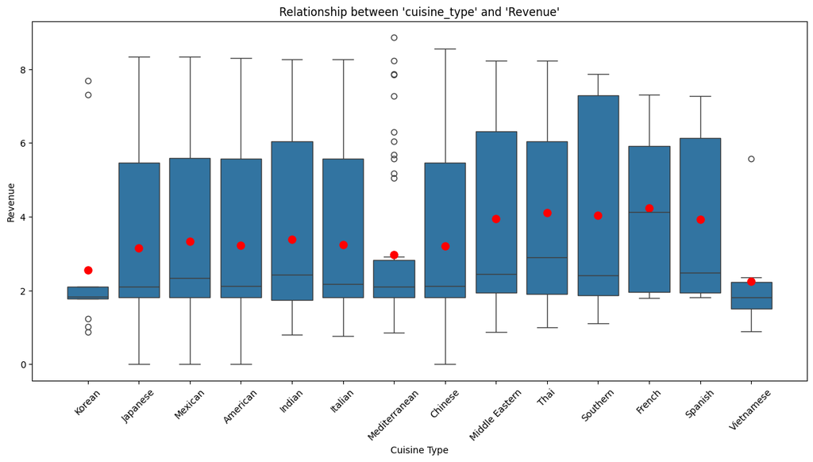

```python
# We'll also compare revenue of each cuisine type
relationship(x = "cuisine_type", y = "Revenue", data=df)
```

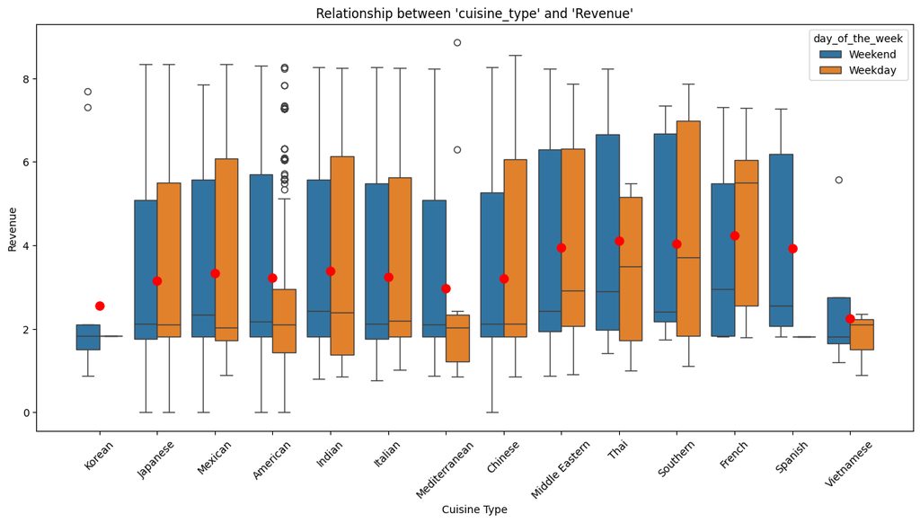

```python
relationship(x = "cuisine_type", y = "Revenue", data=df, hue = "day_of_the_week")
```

### **Question 15:** The company wants to analyze the total time required to deliver the food. What percentage of orders take more than 60 minutes to get delivered from the time the order is placed? (The food has to be prepared and then delivered.) [2 marks]

```python
df['total_time']  = df['delivery_time'] + df['food_preparation_time']
df.head()
```

|  | order_id | customer_id | restaurant_name | cuisine_type | cost_of_the_order | day_of_the_week | rating | food_preparation_time | delivery_time | Revenue | total_time |
| --- | --- | --- | --- | --- | --- | --- | --- | --- | --- | --- | --- |
| 0 | 1477147 | 337525 | Hangawi | Korean | 30.75 | Weekend | NaN | 25 | 20 | 7.6875 | 45 |
| 1 | 1477685 | 358141 | Blue Ribbon Sushi Izakaya | Japanese | 12.08 | Weekend | NaN | 25 | 23 | 1.8120 | 48 |
| 2 | 1477070 | 66393 | Cafe Habana | Mexican | 12.23 | Weekday | 5.0 | 23 | 28 | 1.8345 | 51 |
| 3 | 1477334 | 106968 | Blue Ribbon Fried Chicken | American | 29.20 | Weekend | 3.0 | 25 | 15 | 7.3000 | 40 |
| 4 | 1478249 | 76942 | Dirty Bird to Go | American | 11.59 | Weekday | 4.0 | 25 | 24 | 1.7385 | 49 |

```python
# Calculate percentage of rows with 'total_time'>60
percent60 = round(df[df['total_time'] > 60].shape[0]/df.shape[0]*100, 2)
print (f'Percentage of orders take more than 60 minutes to get delivered: {percent60}%')
```

```
Percentage of orders take more than 60 minutes to get delivered: 10.54%
```

#### Observations:

Percentage of orders that take more than 60 minutes to get delivered is: 10.54%

### **Question 16:** The company wants to analyze the delivery time of the orders on weekdays and weekends. How does the mean delivery time vary during weekdays and weekends? [2 marks]

```python
# Calculate mean delivery time on weekday and weekend:
# Loop through both options, filter the rows by day_of_the_week and calculate mean
# on delivery_time.

for day in ['Weekday','Weekend']:
      mean_del_time = round(df[df['day_of_the_week'] == day]['delivery_time'].mean(),2)
      print(f'The mean delivery time on {day} is {mean_del_time} minutes')
```

```
The mean delivery time on Weekday is 28.34 minutes
The mean delivery time on Weekend is 22.47 minutes
```

#### Observations:

Mean delivery time on weekday is longer (28.3 minutes) than the on weekends (22.5 minutes)

### Conclusion and Recommendations

### **Question 17:** What are your conclusions from the analysis? What recommendations would you like to share to help improve the business? (You can use cuisine type and feedback ratings to drive your business recommendations.) [6 marks]

### Conclusions:

- American cuisine is the most popular cuisine type.
- Other popular cuisines: Japanese, Italian and Chinese.
- Most food orders are on weekends.
- Order price is mostly around 12-22 dollars, with median at ~14 dollars and mean at ~17$.
- Most costumers give good ratings (4-5), but 38% of the data is missing rating score.
- The top 5 restauarnts (by number of orders) are: Shake Shack, The Meatball Shop, Blue Ribbon Sushi, Blue Ribbon Fried Chicken and Parm. These restaurants has also many recurring customers.
- The top-5 restaurants serve Americam, Italian and Japanese cuisines.
- Restaurants with most high ratings are serving American, Italian and Japanese cuisines.
- French and Thai cuisines are the most expensive and gives more revenue per order to the company.
- Delivery time in weekdays takes longer than in weekends.